# Prédictions raster de la température de l’air (Ta) — Rio de Janeiro

Modèle Random Forest spatial à partir des stations météo, LST, NDVI et données environnementales — Script NUIT ET JOUR à adapter

Spagnoli Chloé

19/08/2026

# 1 Introduction

Ce document décrit la méthode complette de prédiction spatiale de la température de l’air (**Ta**) pour les pixels de Rio de Janeiro ne disposant pas de mesure température, à partir des données des stations météo (INMET, Préfecture, Meteostats) et de prédicteurs géographiques et environnementaux (LST, NDVI, MNT, etc.).

Le DataFrame source contient une ligne = une station à une date, avec ses valeurs de Ta, LST, NDVI, etc.

La méthode comprend trois grandes étapes :

1. **Entraînement** du modèle Random Forest sur l’ensemble du jeu de données.
2. **Validation croisée Leave-One-Station-Out (LOSO)**, répétée plusieurs fois pour évaluer la robustesse spatiale du modèle.
3. **Prédiction spatiale** par date, puis calcul et visualisation des cartes de Ta médiane par saison.

> **Note :** ce script correspond à la version **nuit**. Pour la version jour, il faut adapter les patterns de fichiers LST et les fichiers ERA5 RH (voir les commentaires dans le code).

# 2 Packages requis

```r
library(randomForest)
library(terra)
library(caret)
library(lubridate)
library(dplyr)
library(ggplot2)
library(tidyterra)
library(patchwork)
library(conflicted)
```

# 3 Chargement des données et paramètres généraux

## 3.1 Chemins des fichiers et dossiers

```r
df <- read.csv("C:/Users/Spagnoli/Desktop/R/DF_nuit1k_aeroport")

raster_dir   <- "C:/Users/Spagnoli/Desktop/R/predicteurs"
era5TA_dir   <- "C:/Users/Spagnoli/Desktop/R/ERA5/era5_ta_nuit" # rasters ERA5 rangés dans un dossier à part car varient dans le temps
era5RH_dir   <- "C:/Users/Spagnoli/Desktop/R/ERA5/era5_rh_nuit"
output_dir   <- "C:/Users/Spagnoli/Desktop/R/rasters_ta_predite" # dossier de sortie des rasters de Ta prédits
dir.create(output_dir, showWarnings = FALSE)
```

## 3.2 Préparation du jeu de données

```r
dates_uniques    <- sort(unique(df$date))
rasters_produits <- c()

# Enlever les lignes NA dans la colonne Ta (obligatoire pour l'entraînement)
df <- df %>% tidyterra::filter(!is.na(Ta))

# Raster de référence pour emprise et résolution
template_ref <- rast(file.path(raster_dir, "raster_ref_1k.tif"))

# Définition des saisons (si pas déjà indiqué dans le df)
mois_seche  <- c(5, 6, 7, 8, 9, 10)
mois_humide <- c(11, 12, 1, 2, 3, 4)

cat("Nombre de dates à prédire :", length(dates_uniques), "\n")
```

```
## Nombre de dates à prédire : 14
```

## 3.3 Paramètres généraux du modèle

```r
SEED <- 123

COL_STATION <- "nom"
COL_DATE    <- "date"
COL_TARGET  <- "Ta"

# On modifie la formule en fonction des prédicteurs qu'on veut tester
# Attention : un plus grand nombre de prédicteurs n'améliore pas forcément le modèle, cela dépend des données
formula <- Ta ~ LST_pixel + Ta_era5 + MNT + NDVI
```

# 4 Entraînement du Random Forest

L’entraînement du Random Forest repose sur l’entraînement de *n* arbres, chacun construit sur un échantillon bootstrap (63 % des observations). Les 37 % restants ne servent pas à construire cet arbre : ce sont les données **out-of-bag (OOB)**, mais elles proviennent malgré tout de stations déjà représentées dans l’entraînement.

```r
rf_model <- randomForest(
  formula,
  data       = df,
  mtry       = 2,       # p/3 où p = nombre de prédicteurs du modèle
  ntree      = 500,      # nombre d'arbres
  nodesize   = 5,        # taille minimale des nœuds
  importance = TRUE
)

print(rf_model) # affiche la part de variance des données expliquée par le modèle
```

```
##
## Call:
##  randomForest(formula = formula, data = df, mtry = 2, ntree = 500,      nodesize = 5, importance = TRUE)
##                Type of random forest: regression
##                      Number of trees: 500
## No. of variables tried at each split: 2
##
##           Mean of squared residuals: 2.694362
##                     % Var explained: 82.23
```

## 4.1 Importance des variables

L’importance d’un prédicteur correspond au pourcentage d’erreur ajouté si on le retire du modèle.

```r
imp    <- importance(rf_model)
print(imp)
```

```
##            %IncMSE IncNodePurity
## LST_pixel 34.38026     1595.9305
## Ta_era5   30.00950     1217.2482
## MNT       29.76901      282.8126
## NDVI      32.19801      373.0546
```

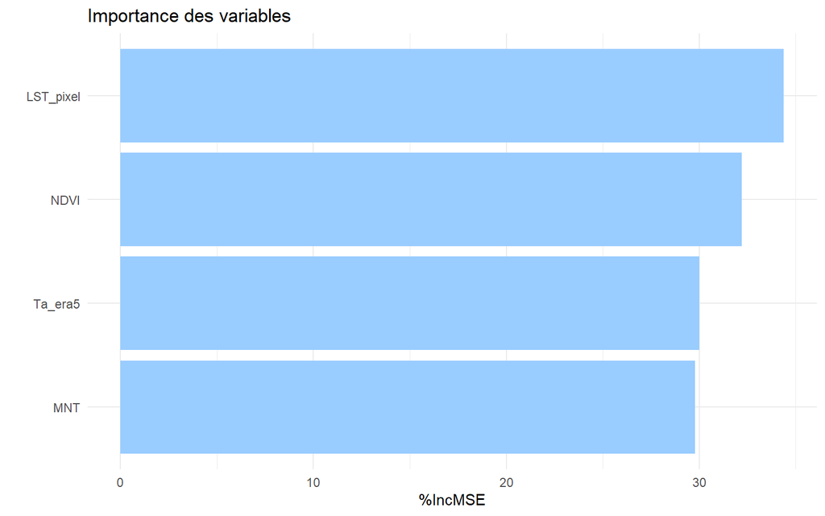

```r
imp_df <- as.data.frame(imp)
imp_df$variable <- rownames(imp_df)

ggplot(imp_df, aes(x = reorder(variable, `%IncMSE`), y = `%IncMSE`)) +
  geom_bar(stat = "identity", fill = "#99CCFF") +
  coord_flip() +
  labs(title = "Importance des variables", x = "", y = "%IncMSE") +
  theme_minimal()
```

## 4.2 Métriques OOB (internes au modèle)

L’erreur OOB est calculée en interne par le Random Forest sur les échantillons bootstrap non utilisés pour construire chaque arbre (les 37 % restants). Ces données OOB proviennent des mêmes stations que les données d’entraînement (l’OOB se fait sur des observations, pas des stations entières). **Ces métriques ne reflètent donc pas la performance réelle du modèle sur un pixel inconnu** — c’est l’objet de la validation LOSO ci-dessous.

```r
cat(sprintf("RMSE OOB (interne RF) : %.3f °C\n", sqrt(rf_model$mse[rf_model$ntree])))
```

```
## RMSE OOB (interne RF) : 1.641 °C
```

```r
cat(sprintf("R²  OOB (interne RF)  : %.4f\n",    rf_model$rsq[rf_model$ntree]))
```

```
## R²  OOB (interne RF)  : 0.8223
```

# 5 Validation croisée Leave-One-Station-Out (LOSO)

Pour chaque station : entraînement sur toutes les autres stations, puis prédiction sur la station laissée de côté, à toutes les dates. On moyenne ensuite les métriques de tous les tests, ce qui répond à la question : *« Si je n’avais pas cette station, le modèle entraîné sur les autres arrive-t-il à prédire correctement sa Ta ? »* — soit une estimation de la capacité de généralisation spatiale du modèle, simulant la prédiction sur un pixel inconnu.

Cette validation est répétée **20 fois** dans une boucle, ce qui permet, pour chaque station, d’obtenir une distribution de R² (boxplot) plutôt qu’une seule valeur, et de vérifier que les résultats ne dépendent pas d’un seul tirage aléatoire.

```r
conflicted::conflicts_prefer(dplyr::filter)

stations_uniques <- unique(df[[COL_STATION]])
n_repetitions    <- 20

resultats_loso_rep <- list()  # stockera toutes les répétitions x stations

cat("\n=== Boucle de validation LOSO répétée (variabilité liée au RF) ===\n")
```

```
##
## === Boucle de validation LOSO répétée (variabilité liée au RF) ===
```

```r
for (rep in 1:n_repetitions) {

  set.seed(rep)  # seed différente à chaque répétition -> tirage bootstrap différent du RF

  for (sta in stations_uniques) {

    loso_train <- df %>%
      filter(.data[[COL_STATION]] != sta)   # toutes les stations sauf une, toutes les dates

    loso_test <- df %>%
      filter(.data[[COL_STATION]] == sta)   # 1 station, toutes les dates

    if (nrow(loso_test) == 0 || nrow(loso_train) == 0) next

    rf_loso <- randomForest(
      formula,
      data     = loso_train,
      mtry     = 2,
      ntree    = 300,
      nodesize = 5
    )

    pred <- predict(rf_loso, newdata = loso_test)
    res  <- loso_test[[COL_TARGET]] - pred

    resultats_loso_rep[[length(resultats_loso_rep) + 1]] <- data.frame(
      repetition = rep,
      station    = sta,
      n          = nrow(loso_test),
      RMSE       = sqrt(mean(res^2)),
      MAE        = mean(abs(res)),
      R2         = 1 - sum(res^2) /
        sum((loso_test[[COL_TARGET]] - mean(loso_test[[COL_TARGET]]))^2),
      Biais      = mean(res)
    )
  }

  if (rep %% 10 == 0) cat(sprintf("  Répétition %d/%d terminée\n", rep, n_repetitions))
}
```

```
##   Répétition 10/20 terminée
##   Répétition 20/20 terminée
```

```r
loso_rep_df <- do.call(rbind, resultats_loso_rep)
```

## 5.1 Synthèse par station

Moyenne et écart-type par station, calculés sur les 20 répétitions.

```r
synthese_station <- loso_rep_df %>%
  group_by(station) %>%
  summarise(
    RMSE_moy = mean(RMSE, na.rm = TRUE),
    RMSE_sd  = sd(RMSE,   na.rm = TRUE),
    R2_moy   = mean(R2,   na.rm = TRUE),
    R2_sd    = sd(R2,     na.rm = TRUE),
    n        = mean(n)
  ) %>%
  arrange(desc(R2_moy))

print(synthese_station)
```

```
## # A tibble: 18 × 6
##    station                        RMSE_moy RMSE_sd R2_moy   R2_sd     n
##    <chr>                             <dbl>   <dbl>  <dbl>   <dbl> <dbl>
##  1 Niteroi                           0.861  0.0230  0.947 0.00281    14
##  2 Santa Cruz                        1.22   0.0232  0.873 0.00484    14
##  3 Seropedica - Ecologia Agricola    1.38   0.0355  0.867 0.00682    14
##  4 Rio - Forte de Copacabana         0.936  0.0446  0.846 0.0145     10
##  5 Rio De Janeiro Aeroporto          1.09   0.0259  0.830 0.00818    14
##  6 Rio - Jacarepagua                 1.92   0.0469  0.825 0.00864    13
##  7 Rio - Marambaia                   1.43   0.0239  0.821 0.00598    14
##  8 Guaratiba                         1.40   0.0245  0.817 0.00645    14
##  9 Rio / Jacarepagua                 1.61   0.0380  0.811 0.00907    13
## 10 Rio - Vila Militar                2.14   0.0311  0.742 0.00754    14
## 11 Galeao                            1.83   0.0434  0.686 0.0149     14
## 12 Afonsos Aeroporto                 2.19   0.0506  0.666 0.0154     13
## 13 Alto da Boa Vista                 2.05   0.0203  0.664 0.00661    14
## 14 Jardim Botanico                   1.30   0.0281  0.638 0.0157      7
## 15 Rio De Janeiro                    2.05   0.0349  0.393 0.0208     14
## 16 Sao Cristovao                     2.36   0.0404  0.378 0.0214     14
## 17 Barra/Riocentro                   2.66   0.0303  0.323 0.0154     14
## 18 Iraja                             3.13   0.0617 -0.124 0.0445     12
```

## 5.2 Synthèse globale

Toutes stations et répétitions confondues.

```r
cat("\n--- Métriques LOSO répétées : moyenne ± écart-type global ---\n")
```

```
##
## --- Métriques LOSO répétées : moyenne ± écart-type global ---
```

```r
cat(sprintf("RMSE : %.3f ± %.3f °C\n", mean(loso_rep_df$RMSE, na.rm = TRUE), sd(loso_rep_df$RMSE, na.rm = TRUE)))
```

```
## RMSE : 1.752 ± 0.600 °C
```

```r
cat(sprintf("R²   : %.4f ± %.4f\n",    mean(loso_rep_df$R2,   na.rm = TRUE), sd(loso_rep_df$R2,   na.rm = TRUE)))
```

```
## R²   : 0.6667 ± 0.2612
```

```r
cat(sprintf("MAE  : %.3f ± %.3f °C\n", mean(loso_rep_df$MAE,  na.rm = TRUE), sd(loso_rep_df$MAE,  na.rm = TRUE)))
```

```
## MAE  : 1.438 ± 0.570 °C
```

```r
cat(sprintf("Biais: %.3f ± %.3f °C\n", mean(loso_rep_df$Biais,na.rm = TRUE), sd(loso_rep_df$Biais,na.rm = TRUE)))
```

```
## Biais: -0.070 ± 1.304 °C
```

## 5.3 Graphiques des métriques LOSO

Définition des couleurs par source, puis ajout de la colonne `source` au tableau des résultats LOSO.

```r
couleurs_source <- c("INMET" = "#FFA500",
                     "Prefecture" = "#9B59B6",
                     "Aeroporto" = "#FF69B4")

loso_rep_df <- loso_rep_df %>%
  left_join(df %>% select(nom, source), by = c("station" = "nom"))

# Ordre des stations tel qu'utilisé dans reorder() (par médiane de R2 ou RMSE)
ordre_stations <- loso_rep_df %>%
  group_by(station) %>%
  summarise(med_R2 = median(R2)) %>% # Modifier R2 ou RMSE selon le graphique voulu
  arrange(med_R2) %>%
  pull(station)

# Association de chaque station à sa couleur (via sa source), dans cet ordre précis
couleurs_stations <- loso_rep_df %>%
  distinct(station, source) %>%
  mutate(color = couleurs_source[source]) %>%
  arrange(match(station, ordre_stations)) %>%
  pull(color)
```

### 5.3.1 Distribution du R² par station

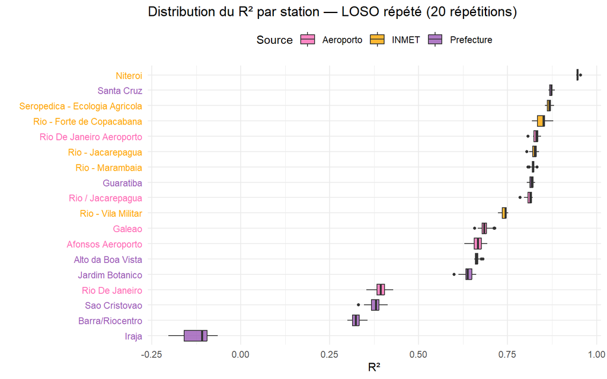

```r
ggplot(loso_rep_df, aes(x = reorder(station, R2, FUN = median), y = R2, fill = source)) +
  geom_boxplot(alpha = 0.8, outlier.size = 1, width = 0.7) +
  scale_fill_manual(values = couleurs_source, name = "Source") +
  coord_flip() +
  labs(title = "Distribution du R² par station — LOSO répété (20 répétitions)",
       x = "", y = "R²") +
  theme_minimal(base_size = 11) +
  theme(legend.position = "top",
        axis.text.y = element_text(colour = couleurs_stations))
```

### 5.3.2 Distribution du RMSE par station

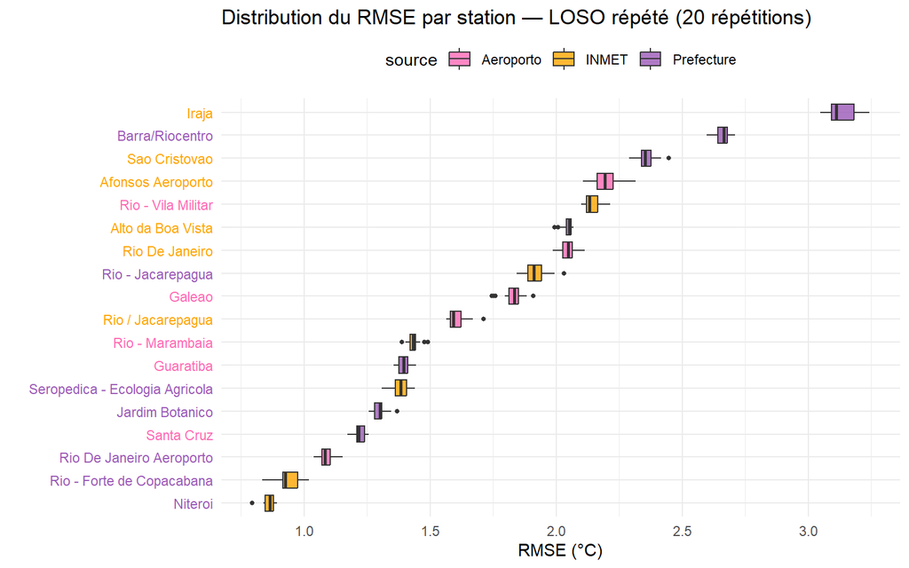

```r
ggplot(loso_rep_df, aes(x = reorder(station, RMSE, FUN = median), y = RMSE, fill = source)) +
  geom_boxplot(alpha = 0.8, outlier.size = 1, width = 0.7) +
  scale_fill_manual(values = couleurs_source, name = "source") +
  coord_flip() +
  labs(title = "Distribution du RMSE par station — LOSO répété (20 répétitions)",
       x = "", y = "RMSE (°C)") +
  theme_minimal(base_size = 11) +
  theme(legend.position = "top",
        axis.text.y = element_text(colour = couleurs_stations))
```

# 6 Boucle de prédiction par date

Le modèle `rf_model`, entraîné sur l’ensemble des données, est utilisé ici pour produire un raster de Ta prédite pour chaque date disponible.

> **À adapter jour/nuit :** le pattern de recherche du fichier LST et le nom du fichier ERA5 RH doivent être modifiés selon qu’on travaille sur la version jour ou nuit (voir commentaires dans le chunk ci-dessous).

```r
for (d in dates_uniques) {

  cat("\nTraitement de la date :", d, "\n")

  # pattern pour nom de fichier en sortie
  nom_fichier <- file.path(output_dir, paste0("Ta_nuit_", gsub("-", "", d), ".tif"))

  if (file.exists(nom_fichier)) {
    cat("  -> Déjà produit, on passe.\n")
    rasters_produits <- unique(c(rasters_produits, nom_fichier))
    next
  }

  tryCatch({

    # Déterminer la saison
    mois_d <- month(as.Date(d))
    saison  <- ifelse(mois_d %in% mois_seche, "seche", "humide")
    cat("  Saison :", saison, "\n")

    # Suffixe des rasters saisonniers (on charge les rasters uniques plus tard)
    sfx_ndvi   <- ifelse(saison == "seche", "NDVI_sec.tif",   "NDVI.tif")
    sfx_ndbi   <- ifelse(saison == "seche", "NDBI_sec.tif",   "NDBI.tif")
    sfx_albedo <- ifelse(saison == "seche", "albedo_sec.tif", "albedo.tif")
    sfx_mndwi  <- ifelse(saison == "seche", "MNDWI_sec.tif",  "MNDWI.tif")

    cat("  Rasters saisonniers :", sfx_ndvi, "|", sfx_ndbi, "|",
        sfx_albedo, "|", sfx_mndwi, "\n")

    # Format des dates
    date_fmt_era5 <- format(as.Date(d), "%d%m%y")
    date_fmt_lst  <- format(as.Date(d), "%Y%m%d")

    # Trouver le fichier LST
    lst_files <- list.files(
      raster_dir,
      #pattern    = paste0("LC0[89]_L2SP_.*_", date_fmt_lst, "_.*_LST_celsius\\.TIF$"), # jour
      pattern = paste0("LC0[89]_L1GT_.*_", date_fmt_lst, "_.*_LST_celsius\\.TIF$"), # nuit
      full.names = TRUE
    )

    if (length(lst_files) == 0) stop(paste("Aucun fichier LST trouvé pour la date", d))
    cat("  LST trouvé :", basename(lst_files[1]), "\n")

    # Charger et reprojeter Ta ERA5
    era5TA_brut   <- rast(file.path(era5TA_dir, paste0("era5_t", date_fmt_era5, ".grib")))
    era5TA_reproj <- project(era5TA_brut, "EPSG:32623", method = "bilinear")

    # Charger et reprojeter RH ERA5
    #era5RH_brut   <- rast(file.path(era5RH_dir,
                            #paste0("era5_h_", format(as.Date(d), "%Y%m%d"), "_13h.grib"))) # jour
    era5RH_brut <- rast(file.path(era5RH_dir,
                           paste0("era5_h_", format(as.Date(d), "%Y%m%d"), "_01h.grib"))) # nuit
    era5RH_reproj <- project(era5RH_brut, "EPSG:32623", method = "bilinear")

    # Charger les rasters (saisonniers + statiques)
    raster_list_d <- list(
      LST_pixel  = rast(lst_files[1]),
      Ta_era5    = era5TA_reproj,
      RH975_era5 = era5RH_reproj,
      NDVI       = rast(file.path(raster_dir, sfx_ndvi)),
      NDBI       = rast(file.path(raster_dir, sfx_ndbi)),
      albedo     = rast(file.path(raster_dir, sfx_albedo)),
      MNDWI      = rast(file.path(raster_dir, sfx_mndwi)),
      MNT        = rast(file.path(raster_dir, "MNT.tif")),
      dist_mer   = rast(file.path(raster_dir, "dist_mer.tif")),
      slope      = rast(file.path(raster_dir, "slope.tif"))
    )

    # Aligner tous les rasters sur le template de référence
    raster_list_d <- lapply(raster_list_d, function(r) {
      if (!compareGeom(r, template_ref, stopOnError = FALSE)) {
        r <- resample(r, template_ref, method = "bilinear")
      }
      r <- crop(r, ext(template_ref))
      r <- mask(r, template_ref)   # applique le masque NA (eau) de template_ref
      r
    })

    # Stack + coordonnées
    raster_stack_d <- rast(raster_list_d)

    coords_d       <- xyFromCell(raster_stack_d, 1:ncell(raster_stack_d))
    X_r            <- rast(template_ref); values(X_r) <- coords_d[, 1]; names(X_r) <- "longitude"
    Y_r            <- rast(template_ref); values(Y_r) <- coords_d[, 2]; names(Y_r) <- "latitude"
    raster_stack_d <- c(raster_stack_d, X_r, Y_r)

    # Vérification des variables du modèle
    model_vars   <- all.vars(formula)[-1]
    missing_vars <- setdiff(model_vars, names(raster_stack_d))
    if (length(missing_vars) > 0) {
      stop(paste("Variables manquantes dans le stack :",
                 paste(missing_vars, collapse = ", ")))
    }

    # Prédiction
    Ta_pred_d <- predict(
      object    = raster_stack_d,
      model     = rf_model,
      filename  = nom_fichier,
      format    = "GTiff",
      overwrite = TRUE
    )

    Ta_pred_d <- mask(Ta_pred_d, template_ref) # applique le masque du template ref en prédiction (sécurité sup.)

    rasters_produits <- unique(c(rasters_produits, nom_fichier))
    cat("  -> Sauvegardé :", basename(nom_fichier), "\n")

  }, error = function(e) {
    cat("  -> ERREUR pour la date", d, ":", conditionMessage(e), "\n")
  })
}

cat("\nNombre de rasters produits :", length(rasters_produits), "/",
    length(dates_uniques), "\n")
```

# 7 Statistiques des rasters produits

```r
cat("\n=== STATISTIQUES DES RASTERS PRODUITS ===\n")

rasters_produits <- unique(rasters_produits)
cat("Après déduplication :", length(rasters_produits), "rasters\n")

stats_rasters <- data.frame()

for (f in rasters_produits) {

  r        <- rast(f)
  date_str <- regmatches(f, regexpr("[0-9]{8}", f))
  date_val <- as.Date(date_str, format = "%Y%m%d")
  mois     <- month(date_val)
  saison   <- ifelse(mois %in% mois_seche, "Sèche", "Humide")

  vals <- values(r, na.rm = TRUE)

  stats_rasters <- rbind(stats_rasters, data.frame(
    date   = date_val,
    saison = saison,
    min    = min(vals),
    q25    = quantile(vals, 0.25),
    median = median(vals),
    mean   = mean(vals),
    q75    = quantile(vals, 0.75),
    max    = max(vals),
    sd     = sd(vals),
    pct_na = round(100 * global(is.na(r), "sum")[[1]] / ncell(r), 1)
  ))
}

stats_rasters <- stats_rasters %>% arrange(date)
```

## 7.1 Distribution des médianes par saison

```r
ggplot(stats_rasters, aes(x = saison, y = median, fill = saison)) +
  geom_boxplot() +
  scale_fill_manual(values = c("Sèche" = "#d6604d", "Humide" = "#2166ac")) +
  labs(title = "Distribution des médianes par saison",
       x = "", y = "Ta médiane (°C)") +
  theme_minimal()
```

# 8 Calcul des médianes par saison

```r
cat("\nChargement des rasters produits...\n")

raster_stack_all <- list()
dates_rasters    <- c()

for (f in rasters_produits) {
  date_str              <- regmatches(f, regexpr("[0-9]{8}", f))
  date_val              <- as.Date(date_str, format = "%Y%m%d")
  raster_stack_all[[f]] <- rast(f)
  dates_rasters         <- c(dates_rasters, date_val)
}

dates_rasters <- as.Date(dates_rasters, origin = "1970-01-01")

idx_seche  <- which(month(dates_rasters) %in% mois_seche)
idx_humide <- which(month(dates_rasters) %in% mois_humide)

cat("Rasters saison sèche  :", length(idx_seche),  "\n")
cat("Rasters saison humide :", length(idx_humide), "\n")

cat("Calcul médiane saison sèche...\n")
stack_seche    <- rast(raster_stack_all[idx_seche])
mediane_seche  <- app(stack_seche,  fun = median, na.rm = TRUE)

cat("Calcul médiane saison humide...\n")
stack_humide   <- rast(raster_stack_all[idx_humide])
mediane_humide <- app(stack_humide, fun = median, na.rm = TRUE)

writeRaster(mediane_seche,  file.path(output_dir, "mediane_Ta_nuit_saison_seche.tif"),  overwrite = TRUE)
writeRaster(mediane_humide, file.path(output_dir, "mediane_Ta_nuit_saison_humide.tif"), overwrite = TRUE)
cat("Médianes sauvegardées.\n")
```

## 8.1 Statistiques des rasters médians

```r
stats_finale <- data.frame()

for (info in list(
  list(r = mediane_seche,  saison = "Sèche"),
  list(r = mediane_humide, saison = "Humide")
)) {
  vals <- values(info$r, na.rm = TRUE)
  stats_finale <- rbind(stats_finale, data.frame(
    Saison = info$saison,
    Min    = round(min(vals),              2),
    Q25    = round(quantile(vals, 0.25),   2),
    Median = round(median(vals),           2),
    Mean   = round(mean(vals),             2),
    Q75    = round(quantile(vals, 0.75),   2),
    Max    = round(max(vals),              2),
    SD     = round(sd(vals),               2),
    Pct_NA = round(100 * sum(is.na(values(info$r))) / ncell(info$r), 1)
  ))
}

print(stats_finale)
```

## 8.2 Distribution des pixels par saison

```r
vals_all <- rbind(
  data.frame(Ta = as.vector(values(mediane_seche,  na.rm = TRUE)), Saison = "Sèche"),
  data.frame(Ta = as.vector(values(mediane_humide, na.rm = TRUE)), Saison = "Humide")
)

ggplot(vals_all, aes(x = Saison, y = Ta, fill = Saison)) +
  geom_boxplot() +
  scale_fill_manual(values = c("Sèche" = "#d6604d", "Humide" = "#2166ac")) +
  labs(title = "Distribution des pixels — Ta médiane par saison",
       x = "", y = "Ta médiane (°C)") +
  theme_minimal()
```

# 9 Visualisation : cartes des médianes de Ta

## 9.1 Saison sèche (mai – octobre)

```r
val_min_sec <- global(mediane_seche, "min", na.rm = TRUE)[[1]]
val_max_sec <- global(mediane_seche, "max", na.rm = TRUE)[[1]]

ggplot() +
  geom_spatraster(data = mediane_seche, maxcell = Inf) +
  scale_fill_viridis_c(
    option = "turbo",
    limits = c(val_min_sec, val_max_sec),
    name   = "Ta médiane (°C)",
    breaks = seq(val_min_sec, val_max_sec, length.out = 6),
    labels = function(x) paste0(round(x, 1), " °C")
  ) +
  labs(title    = "Saison sèche (mai – octobre)",
       subtitle = "Médiane Ta prédite | 1km | Random Forest") +
  theme_minimal() +
  theme(plot.title    = element_text(hjust = 0.5, face = "bold"),
        plot.subtitle = element_text(hjust = 0.5, color = "gray40"))
```

## 9.2 Saison humide (novembre – avril)

```r
val_min_hum <- global(mediane_humide, "min", na.rm = TRUE)[[1]]
val_max_hum <- global(mediane_humide, "max", na.rm = TRUE)[[1]]

ggplot() +
  geom_spatraster(data = mediane_humide, maxcell = Inf) +
  scale_fill_viridis_c(
    option = "turbo",
    limits = c(val_min_hum, val_max_hum),
    name   = "Ta médiane (°C)",
    breaks = seq(val_min_hum, val_max_hum, length.out = 6),
    labels = function(x) paste0(round(x, 1), " °C")
  ) +
  labs(title    = "Saison humide (novembre – avril)",
       subtitle = "Médiane Ta prédite | 1km | Random Forest") +
  theme_minimal() +
  theme(plot.title    = element_text(hjust = 0.5, face = "bold"),
        plot.subtitle = element_text(hjust = 0.5, color = "gray40"))
```

# 10 Notes finales

- Ce document est prévu pour la condition **nuit** Pour la condition **jour**, il faut :
  - décommenter les lignes marquées `# jour` et commenter celles marquées `# nuit` (pattern LST, fichier ERA5 RH) ;
  - adapter le pattern de recherche des fichiers LST (`L2SP` pour le jour vs `L1GT` pour la nuit).
- Les chunks de la boucle de prédiction par date et des étapes suivantes sont en `eval=FALSE` car ils dépendent de chemins de fichiers locaux (`C:/Users/Spagnoli/...`) et peuvent être longs à exécuter. Passer `eval=TRUE` (ou l’omettre) une fois les chemins vérifiés et l’environnement prêt à tourner.